# HW 3: Visualization, Ggplot2 & Maps

Data 180, Professor Kennedy

Tommy Eaton

eatont@dickinson.edu

October 18, 2023

Make sure that you have accepted the hw invitation link, and working with your clone repository.

**Due date:** October 12 beginning of class.

**Reminder:** You can insert R code in your Rmd file as a chunk in the following way:

```r
# Your code goes here
```

Make sure to insert a chunk for each (sub)section of the assignment.

**Theme of the assignment**: This time we will practice visualization using ggplot2, and create cool maps. Load in the `Cars93` dataset by running the following code chunk:

```r
library(ggplot2) # keep in mind you have to install ggplot2 first via install.packages() if it's not installed in your machine
library(MASS)
data(Cars93)
head(Cars93)
```

```
##   Manufacturer   Model    Type Min.Price Price Max.Price MPG.city MPG.highway
## 1        Acura Integra   Small      12.9  15.9      18.8       25          31
## 2        Acura  Legend Midsize      29.2  33.9      38.7       18          25
## 3         Audi      90 Compact      25.9  29.1      32.3       20          26
## 4         Audi     100 Midsize      30.8  37.7      44.6       19          26
## 5          BMW    535i Midsize      23.7  30.0      36.2       22          30
## 6        Buick Century Midsize      14.2  15.7      17.3       22          31
##              AirBags DriveTrain Cylinders EngineSize Horsepower  RPM
## 1               None      Front         4        1.8        140 6300
## 2 Driver & Passenger      Front         6        3.2        200 5500
## 3        Driver only      Front         6        2.8        172 5500
## 4 Driver & Passenger      Front         6        2.8        172 5500
## 5        Driver only       Rear         4        3.5        208 5700
## 6        Driver only      Front         4        2.2        110 5200
##   Rev.per.mile Man.trans.avail Fuel.tank.capacity Passengers Length Wheelbase
## 1         2890             Yes               13.2          5    177       102
## 2         2335             Yes               18.0          5    195       115
## 3         2280             Yes               16.9          5    180       102
## 4         2535             Yes               21.1          6    193       106
## 5         2545             Yes               21.1          4    186       109
## 6         2565              No               16.4          6    189       105
##   Width Turn.circle Rear.seat.room Luggage.room Weight  Origin          Make
## 1    68          37           26.5           11   2705 non-USA Acura Integra
## 2    71          38           30.0           15   3560 non-USA  Acura Legend
## 3    67          37           28.0           14   3375 non-USA       Audi 90
## 4    70          37           31.0           17   3405 non-USA      Audi 100
## 5    69          39           27.0           13   3640 non-USA      BMW 535i
## 6    69          41           28.0           16   2880     USA Buick Century
```

# Ggplot2

## Task 1

Create a simple scatterplot using ggplot2 where x axis shows `EngineSize`, y axis shows `MPG.city`.

- Use blue color for your dots.
- Use size = 2 for the dot sizes.
- Use xlim and ylim to make sure your x and y axis ranges make sense.
- Add a title, subtitle, x axis label, y axis label, and a caption using title, subtitle, caption options inside `+ labs()`.

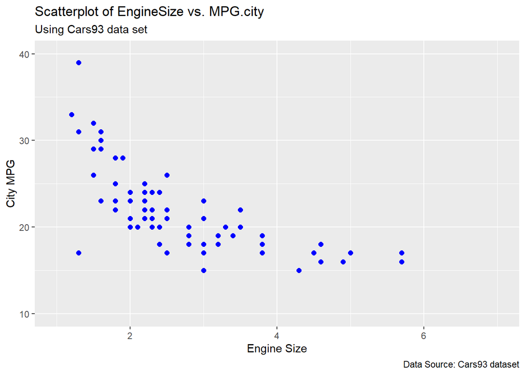

```r
ggplot(data = Cars93, aes(x= EngineSize, y= MPG.city))+ geom_point(color="blue", size = 2) + xlim(1,7) + ylim(10,40) + labs(title= "Scatterplot of EngineSize vs. MPG.city", subtitle = "Using Cars93 data set", x= "Engine Size", y = "City MPG", caption = "Data Source: Cars93 dataset")
```

## Task 2

Recreate the scatterplot in Task 1. Add the following functionality:

- Use a different color for each car `Type`.

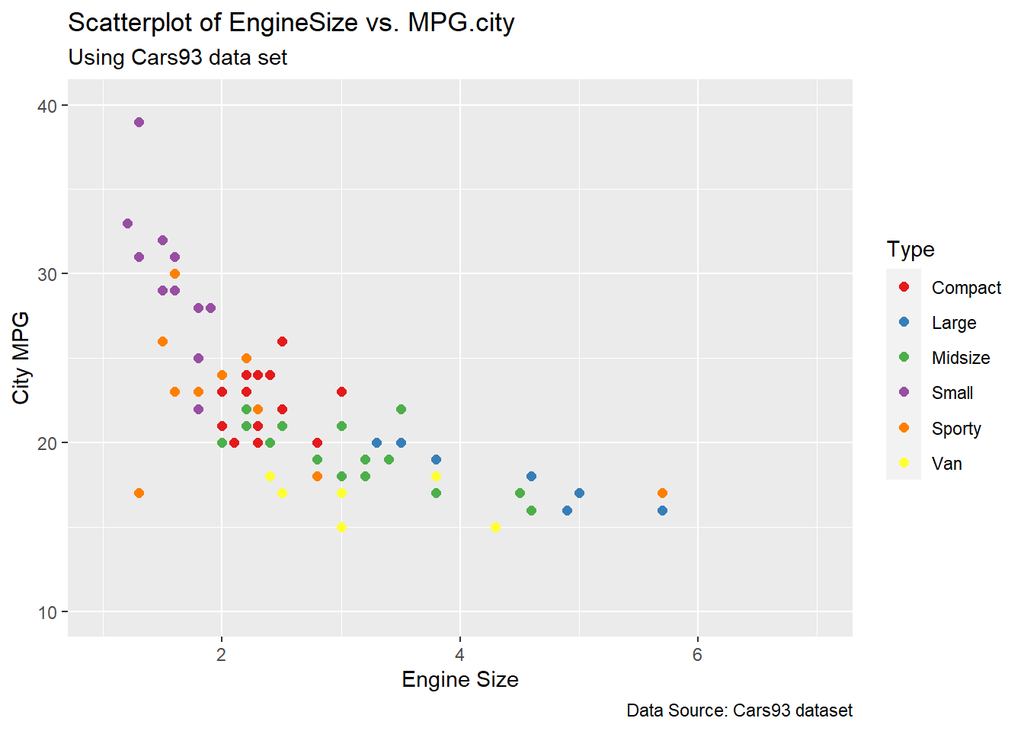

```r
ggplot(data = Cars93, aes(x= EngineSize, y= MPG.city, color= Type))+ geom_point( size = 2) + xlim(1,7) + ylim(10,40) + labs(title= "Scatterplot of EngineSize vs. MPG.city", subtitle = "Using Cars93 data set", x= "Engine Size", y = "City MPG", caption = "Data Source: Cars93 dataset") + scale_color_brewer(palette = "Set1")
```

## Task 3

Recreate the scatterplot in Task 2. Add the following functionality:

- Fit and overlay a smooth curve.
- Make the curve line red, and dashed. (Hint linetype is the option you can use to set line style as ‘dashed’)

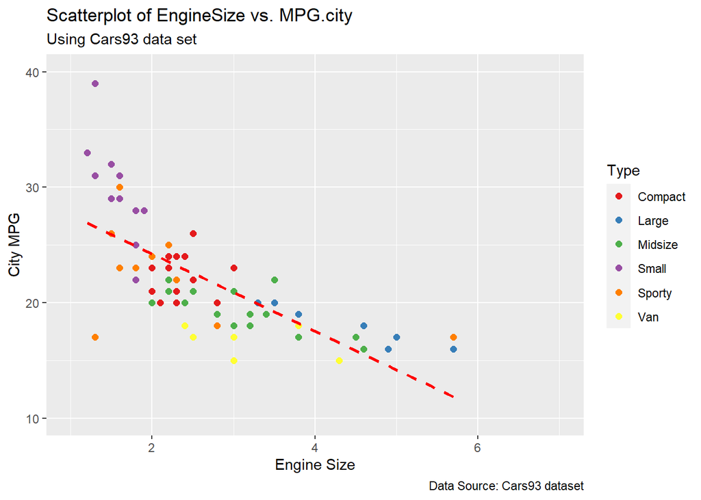

```r
ggplot(data = Cars93, aes(x= EngineSize, y= MPG.city, color= Type))+ geom_point( size = 2) + geom_smooth(method = "lm", se = FALSE, color = "red", linetype= "dashed") + xlim(1,7) + ylim(10,40) + labs(title= "Scatterplot of EngineSize vs. MPG.city", subtitle = "Using Cars93 data set", x= "Engine Size", y = "City MPG", caption = "Data Source: Cars93 dataset") + scale_color_brewer(palette = "Set1")
```

## Task 4

Create a barplot showing count of cars by `AirBags` using ggplot2.

- `geom_bar()` is the function that creates a barplot.
- Use a different color for each bar.
- Add a title, subtitle, x axis label, y axis label, and a caption using title, subtitle, caption options inside `+ labs()`.

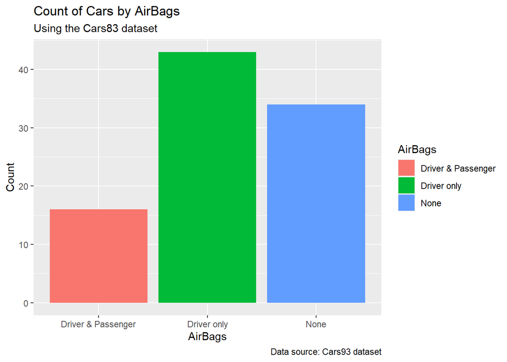

```r
ggplot(data = Cars93, aes(x= AirBags, fill = AirBags)) + geom_bar()+ labs(title = "Count of Cars by AirBags", subtitle = "Using the Cars83 dataset", x = "AirBags", y = "Count", caption = "Data source: Cars93 dataset")
```

## Task 5

Recreate the barplot in Task 4 for different car `Origin`, such that you create one barplot for each `Origin` category and display all on the same graph.

- You can have `Origin` as the “x” variable by setting `x=Origin.`
- Use `fill=AirBags` to get a different color (and bar) by `AirBags`.
- in `geom_bar(), use`position=‘dodge’` to have the barplots side by side.

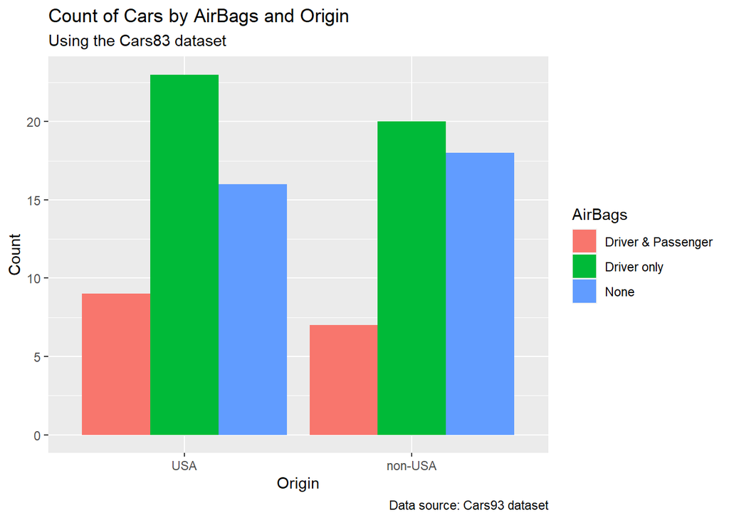

```r
ggplot(data = Cars93, aes(x= Origin, fill = AirBags)) + geom_bar(position = "dodge") + labs(title = "Count of Cars by AirBags and Origin", subtitle = "Using the Cars83 dataset", x = "Origin", y = "Count", caption = "Data source: Cars93 dataset")
```

# Maps

Load Australia’s state map data via running:

```r
# install the packages below by uncommenting the lines. You need to do this only once.
#install.packages('ozmaps') # downloads the map needed
#install.packages('sf') # package used to analyze spatial data
library(ozmaps)
library(sf)
au_states <- ozmaps::ozmap_states # read in spatial dataframe object

# Display the data
head(au_states)
```

```
## Simple feature collection with 6 features and 1 field
## Geometry type: MULTIPOLYGON
## Dimension:     XY
## Bounding box:  xmin: 112.9211 ymin: -43.63203 xmax: 153.6299 ymax: -9.229287
## Geodetic CRS:  GDA94
## # A tibble: 6 × 2
##   NAME                                                                  geometry
##   <chr>                                                       <MULTIPOLYGON [°]>
## 1 New South Wales   (((150.7016 -35.12286, 150.6611 -35.11782, 150.6373 -35.146…
## 2 Victoria          (((146.6196 -38.70196, 146.6721 -38.70259, 146.6744 -38.713…
## 3 Queensland        (((148.8473 -20.3457, 148.8722 -20.37575, 148.8515 -20.3809…
## 4 South Australia   (((137.3481 -34.48242, 137.3749 -34.46885, 137.3805 -34.497…
## 5 Western Australia (((126.3868 -14.01168, 126.3625 -13.98264, 126.3765 -13.974…
## 6 Tasmania          (((147.8397 -40.29844, 147.8902 -40.30258, 147.8812 -40.325…
```

Notice that `NAME` includes the name of a state, `geometry` includes spatial coordinate data for each state polygon (area).

## Task 1

Create a map of Australia using `ggplot2`.

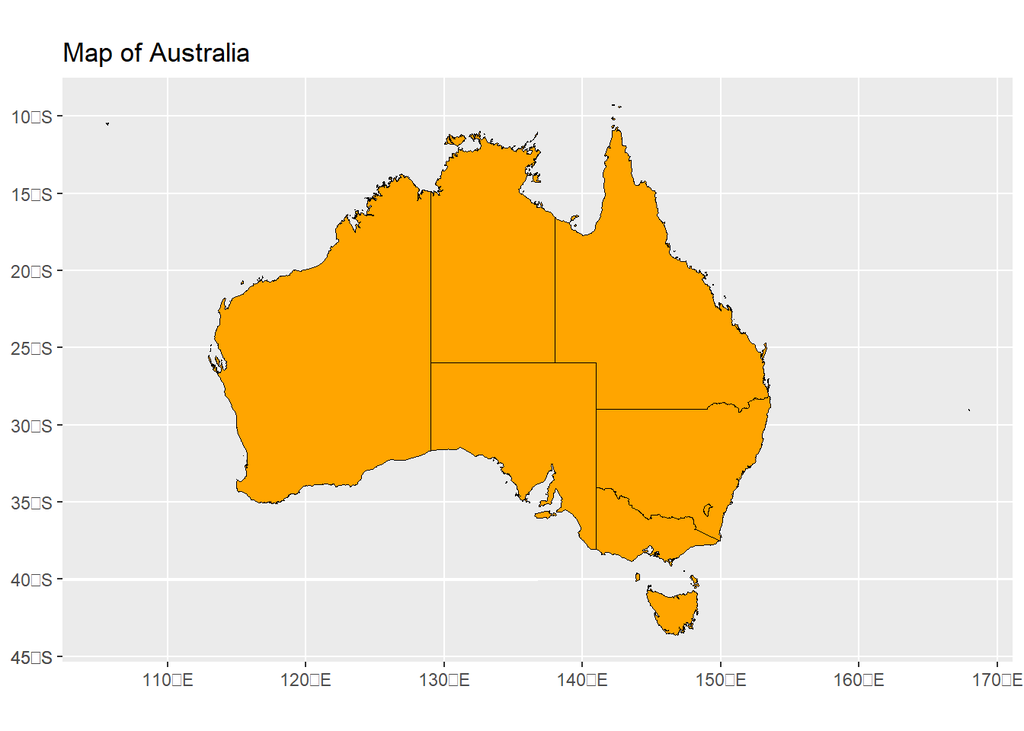

```r
ggplot() + geom_sf(data = au_states, fill = "orange", color = "black") + labs(title = "Map of Australia")
```

## Task 2

Modify your map such that each state is displayed with a different color. (Hint: use the fill option as an aes setting with variable `NAME`.)

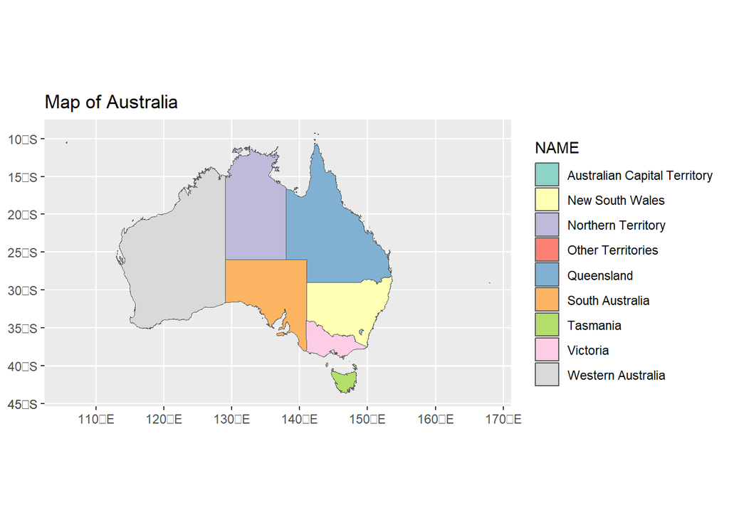

```r
ggplot(data = au_states) + geom_sf(aes(fill = NAME)) + scale_fill_brewer(palette = "Set3") + labs(title = "Map of Australia")
```

## Task 3 Read in the capital city dataframe showing each capital and its latitude and longitude information by running:

```r
au_capitals <- tibble::tribble(
  ~city,           ~lat,     ~lon,
  "Sydney",    -33.8688, 151.2093,
  "Melbourne", -37.8136, 144.9631,
  "Brisbane",  -27.4698, 153.0251,
  "Adelaide",  -34.9285, 138.6007,
  "Perth",     -31.9505, 115.8605,
  "Hobart",    -42.8821, 147.3272,
  "Canberra",  -35.2809, 149.1300,
  "Darwin",    -12.4634, 130.8456,
)
```

Display the capitals as points on your map from Task 1. (Hint: combine `geom_sf()` with `+ geom_point()`)

- Use `col = "red"` such that points are displayed in red color.
- Use `size=2` to make points larger.

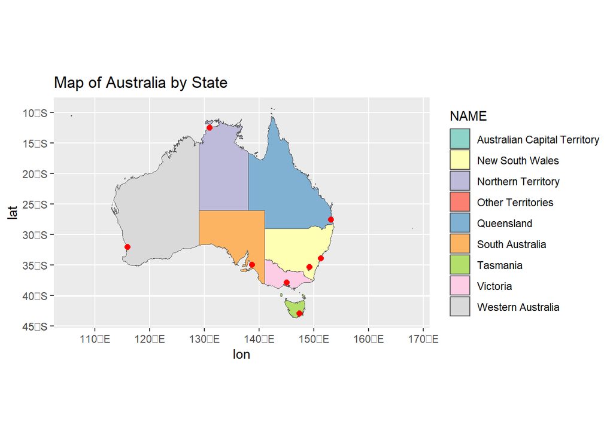

```r
au_map <- ggplot(data = au_states) + geom_sf(aes(fill = NAME)) + scale_fill_brewer(palette = "Set3") + labs(title = "Map of Australia by State")
au_map + geom_point(data = au_capitals, aes(x = lon, y = lat), col = "red", size = 2)
```

## Task 4

Let’s take a look at a different projection output. Change your map’s projection to epsg 3112 by adding `+ coord_sf()`. Recall the option that goes inside `coord_sf()` is `st_crs(4_digit_code)`

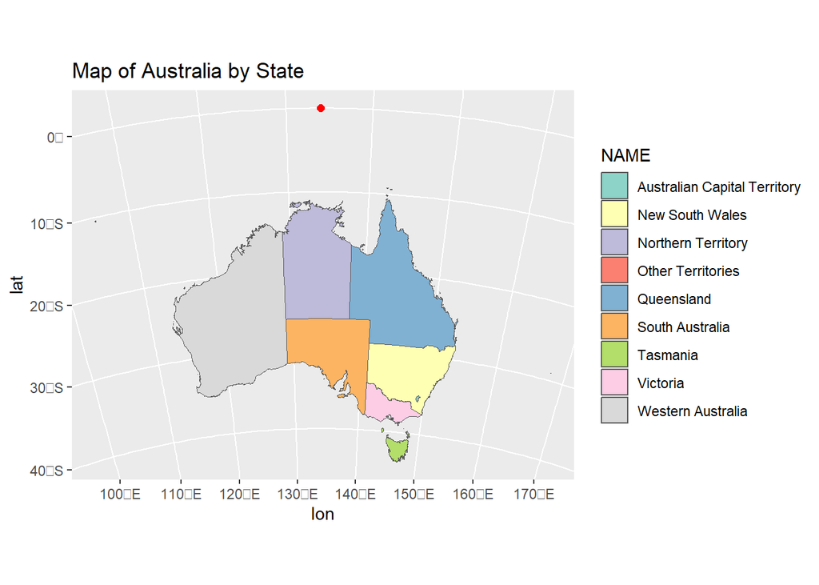

```r
finals_map <- ggplot(data = au_states) + geom_sf(aes(fill = NAME)) + scale_fill_brewer(palette = "Set3") + labs(title = "Map of Australia by State")
finals_map + geom_point(data = au_capitals, aes(x = lon, y = lat), col = "red", size = 2) + coord_sf(crs = st_crs(3112))
```

## Task 5

Lastly, let’s display the same map using `mapview()`. Load the `mapview` package.

```r
#install.packages('mapview') # interactive display
library(mapview)
```

Create an interactive map of Australia using `mapview()`

```r
mapview(au_states)
```

[interactive chart not shown]

## Task 6

Let’s display the capitals on the map like before. First convert the `au_capitals` dataframe to spatial dataframe object by running:

```r
capitals_geo <- st_as_sf(au_capitals, coords = c("lon", "lat"))
```

Now add the new spatial capitals object via + (that is, you can use the following syntax to add a layer: `mapview() + mapview()`)

- You can use the option `col.regions='red'` to make capitals appear in color red, and `legend=F` in second `mapview()` to remove the uninformative second set of legend.

```r
mapview(au_states) + mapview(capitals_geo, col.regions = "red", legend = F)
```

[interactive chart not shown]

You are done! 🏁 Don’t forget to commit and push your .Rmd file to your Github repository before the due date.